# Do two conditions differ?

A common question: does behaviour differ between two conditions? Here we demonstrate a workflow for answering this question with FoMo. For this example, we are interested in whether people’s tendency to stick with the item class they just selected differs between two conditions?

A complication to testing this with a multi-level framework (i.e., data from several people) is that the question splits in two: do the conditions differ **on average**, and do **individuals** behave differently in the two conditions? This example builds three datasets, one for each answer, and fits each with three models, one for each answer:

| Dataset | On average | Individually |
| --- | --- | --- |
| **average** | people stick more in condition one | each person differs between conditions |
| **individual** | no difference | each person differs between conditions |
| **none** | no difference | each person the same in both |

| Model | Population values | Each person’s values |
| --- | --- | --- |
| **condition** | one set per condition | differ between conditions |
| **person x condition** | one set for both | differ between conditions |
| **pooled** | one set for both | the same in both |

The design is **within subjects**: every person does both conditions. (Between-subjects designs aren’t supported well yet: see `ToDo.md`.)

Code: `condition_difference.R`.

```r
source("../../../../functions/set_up_FoMo.R")
```

```
[1] "set_up_FoMo.R: random seed set to 65 (FOMO_SEED)"
```

```r
# iterations per chain (warmup and sampling); the page uses 500
n_iter <- as.integer(Sys.getenv("FOMO_EXAMPLE_ITER", "500"))

# where the fitted models are saved (see "fit" below)
fits_file <- "condition_difference_fits.rds"
```

## 1 Simulate

Ten people, each doing 10 trials in each of two conditions, on an 8 x 8 grid with a quarter of cells empty and two item classes (the multi-level cat model). Each person’s values vary around the population values: the simulation draws a between-person SD for each parameter (from an exponential with rate `sd_lambda`), then each person’s values.

- **average**: condition one is sticky on average (the next item is the same class as the last with probability 0.8, for both classes); condition two has no stick bias (0.5). Each person’s values are drawn separately in each condition.
- **individual**: no stick bias on average in either condition, but each person’s values are again drawn separately in each condition, so every person behaves a little differently in the two.
- **none**: one set of values per person, used in both conditions.

Distance, turning and direction have the same population values throughout.

```r
# 10 people, each doing 10 trials in each of two conditions, on an 8 x 8
# grid with two item classes
spec <- list(K = 2, nrow = 8, ncol = 8, prop_missing = 0.25, v_type = "cat", n_classes = 2)
stim <- generate_stim(spec, n_trials = 10, n_people = 10)
```

Two relabellings: merging the conditions, and numbering each person x condition as its own “person”. The **none** data are simulated with the conditions merged (one set of values per person), then given their conditions back; the models below use the same functions.

```r
# The "pooled" and "person x condition" models are the same model as the
# "condition" model, fitted to relabelled data.

# merge_conditions(): call both conditions "both", so the model estimates
# one set of values that applies to every trial
merge_conditions <- function(d) {
  mutate(d, condition = factor("both"))
}

# person_by_condition(): as above, but also give each person a new number
# in each condition, so that person 1 in condition one and person 1 in
# condition two are treated as two different people
person_by_condition <- function(d) {
  d |>
    mutate(person = paste(person, condition),
           person = as.integer(factor(person, levels = unique(person)))) |>
    merge_conditions()
}
```

```r
# Stickiness: the probability of picking the same item class again.
# "sticky" stays with probability 0.8, "no_bias" with 0.5 (no preference).
# (Each column of the matrix gives the next class after one class.)
sticky  <- matrix(c(0.8, 0.2,
                    0.2, 0.8), nrow = 2)
no_bias <- matrix(0.5, nrow = 2, ncol = 2)

# Everything else is the same everywhere: attraction to nearby items,
# turning, and a preference for moving right and along the grid. People
# vary around these population values (sd_lambda sets how much: a larger
# value means less spread). n_cond: the number of conditions
other_params <- function(n_cond) {
  list(rho_delta_mu = rep(1, n_cond),
       rho_psi_mu = rep(-0.5, n_cond),
       fourier_coef_mu = matrix(c(0.8, 0, 0, 0, 0.5, 0), nrow = n_cond, ncol = 6, byrow = TRUE),
       sd_lambda = list(b_v = 3,
                        rho_delta = rep(6, n_cond),
                        rho_psi = rep(6, n_cond),
                        fourier_coef = c(8, 8, 8)))
}

# Simulate one dataset, then put the real person and condition labels back
# (the "none" data are simulated with the conditions merged)
simulate <- function(stim_for_sim, params) {
  sl <- prep_stan_list(stim_for_sim, params)
  sim <- sim_fomo(sl, iter = 1, chains = 1)
  sim$draws()   # read the simulated values into memory, so they can be saved

  found <- extract_pred(sim, stim_for_sim) |>
    truncate_trials(lambda = 2, min_keep = 10) |>
    select(-person, -condition) |>
    left_join(distinct(stim, trial, person, condition), by = "trial")

  list(found = found, sim = sim)
}

sims <- list(
  # each condition has its own population values, and each person's values
  # are drawn separately in each condition
  average    = simulate(stim, c(other_params(2), list(b_v_pr = list(sticky, no_bias)))),
  individual = simulate(stim, c(other_params(2), list(b_v_pr = list(no_bias, no_bias)))),
  # simulated with the conditions merged: each person has one set of
  # values, used in both conditions
  none       = simulate(merge_conditions(stim), c(other_params(1), list(b_v_pr = list(no_bias)))))

# the selections in each dataset
found <- map(sims, "found")
```

Sticky behaviour shows in the runs of same-class selections: fewer and longer in condition one of the **average** data.

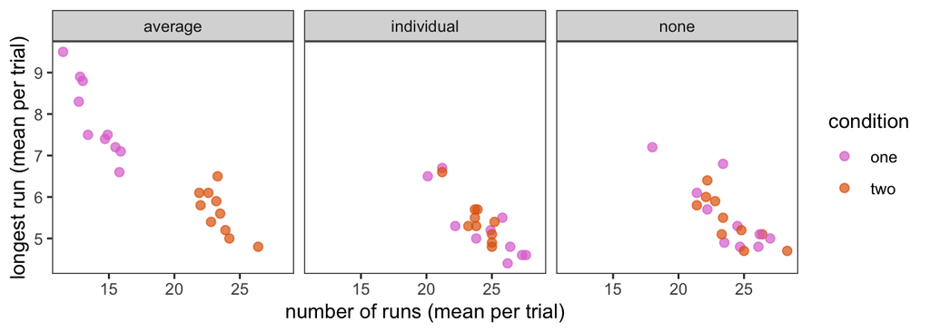

Figure 1: Runs of same-class selections, per person and condition (mean per trial): number of runs and the longest run.

```r
# Runs of same-class selections: sticky behaviour gives fewer, longer runs.
# One point per person and condition (averaged over their trials)
runs <- bind_rows(map(found, compute_runs), .id = "data") |>
  summarise(n_runs = mean(n_runs),
            longest_run = mean(max_run_length),
            .by = c(data, person, condition))

ggplot(runs, aes(n_runs, longest_run, colour = condition)) +
  geom_point(size = 2, alpha = 0.7) +
  facet_wrap(~data) +
  labs(x = "number of runs (mean per trial)", y = "longest run (mean per trial)")
```

## 2 Three models, by relabelling

All three models are the standard multi-level cat model, fitted to relabelled data: the **condition** model to the data as they are; the **pooled** model with the two condition labels merged; and the **person x condition** model with the labels merged and each person x condition counted as a separate “person”, so one set of population values with each person’s values in the two conditions drawn independently. All three predict the same trials, so loo compares them directly. The relabelling functions are defined above, where the **none** data are simulated with the conditions merged.

Fitting all nine models (three datasets x three models) takes about an hour, so it isn’t done when this page is built. The code below is run once, by running `condition_difference.R` itself, and saves the fits in `condition_difference_fits.rds`; the page then loads that file. To refit, delete the file and run the script again.

```r
# The three models: the same multi-level model, with the data relabelled
models <- list(condition            = identity,   # the data as they are
               `person x condition` = person_by_condition,
               pooled               = merge_conditions)

# Fit every model to every dataset (nine fits, about an hour) and save them.
# centred_params = "none": with only 10 trials per person and condition,
# the model samples better this way (see prep_stan_list())
if (!file.exists(fits_file)) {
  fits <- list()
  for (data in names(found)) {
    for (model in names(models)) {
      relabel <- models[[model]]
      sl <- prep_stan_list(relabel(stim), found = relabel(found[[data]]),
                           centred_params = "none")
      fits[[data]][[model]] <- fit_fomo(sl, iter = n_iter)
    }
  }
  saveRDS(list(found = found, sims = sims, fits = fits), fits_file)
}
```

```r
# Load the saved fits, and check they were made from these simulated data
saved <- readRDS(fits_file)
stopifnot("The saved fits were made from different data: delete condition_difference_fits.rds and run this script again" =
            identical(saved$found, found))
fits <- saved$fits
sims <- saved$sims
```

The person x condition model treats a person’s two conditions as two unrelated people. Real people are more consistent than that (someone sticky in one condition is likely sticky in the other); a model with a stable part per person plus a condition-specific part would capture it, and is planned (see “trait + state” in `ToDo.md`).

## 3 How big is the difference?

```r
# Stickiness on the model's own scale: the stay probabilities, the chance
# of picking the same class again after class 1, and after class 2 (the
# diagonal of the class-transition matrix, b_v). extract_post() gives the
# transition probabilities, with columns prev_class (the class just
# picked), class (the next one) and value (the probability).
stay_probabilities <- function(transitions) {
  transitions |>
    filter(prev_class == class) |>
    mutate(class = paste("after class", class),
           condition = as.character(condition)) |>
    rename(stay = value)
}

# the condition model's posterior for each dataset...
post <- map2(fits, found, \(f, d) extract_post(f$condition, d, stim))
# ...and the values each simulation used (the "none" data were simulated
# with the conditions merged, so they are read with the conditions merged)
truth <- list(average    = extract_post(sims$average$sim, found$average),
              individual = extract_post(sims$individual$sim, found$individual),
              none       = extract_post(sims$none$sim, merge_conditions(found$none)))

# the population stay probabilities (every posterior draw)
population <- bind_rows(map(post, \(p) stay_probabilities(filter(p$cat, dist == "posterior"))),
                        .id = "data")

# each person's stay probabilities: estimated (every posterior draw), and
# the values the simulation used
person <- bind_rows(map(post, \(p) stay_probabilities(filter(p$u$cat, dist == "posterior"))),
                    .id = "data")
person_true <- bind_rows(map(truth, \(p) stay_probabilities(p$u$cat)), .id = "data")

# in the "none" data each person's values apply to both conditions
both <- filter(person_true, condition == "both")
person_true <- bind_rows(filter(person_true, condition != "both"),
                         mutate(both, condition = "one"),
                         mutate(both, condition = "two"))
```

### 3.1 The population

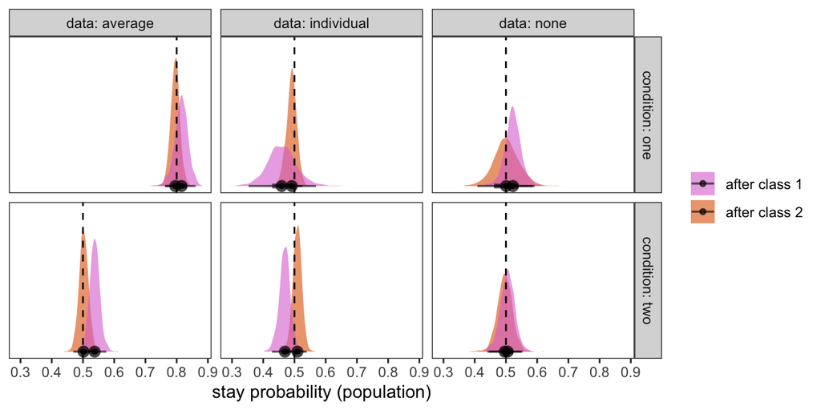

Figure 2: Each condition’s population stay probabilities (after class 1 and after class 2), from the condition model: medians with 53% and 97% HPDIs. Dashed lines: the simulated values.

```r
# The population stay probabilities, with the simulated values (dashed):
# 0.8 in condition one of the "average" data, 0.5 everywhere else
true_stay <- expand_grid(data = names(found), condition = c("one", "two")) |>
  mutate(stay = if_else(data == "average" & condition == "one", 0.8, 0.5))

ggplot(population, aes(stay, fill = class)) +
  ggdist::stat_halfeye(.width = FOMO_HPDI_WIDTHS, point_interval = "median_hdci", alpha = 0.6) +
  geom_vline(aes(xintercept = stay), data = true_stay, linetype = "dashed") +
  facet_grid(condition ~ data, labeller = label_both) +
  labs(x = "stay probability (population)", y = NULL, fill = NULL) +
  theme(axis.text.y = element_blank(), axis.ticks.y = element_blank())
```

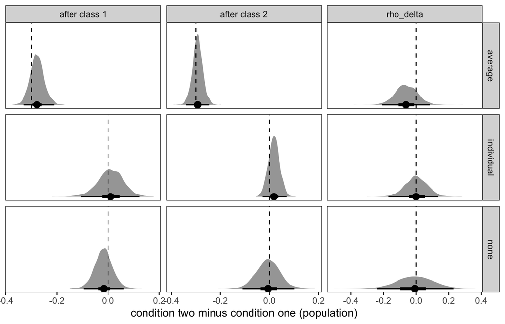

Figure 3: Posterior of condition two minus condition one (population values): the two stay probabilities and distance attraction, from the condition model. Medians with 53% and 97% HPDIs; dashed lines: the simulated differences.

```r
# (1) How big is each difference? Condition two minus condition one, for
# the two stay probabilities, and for distance attraction (rho_delta),
# which is the same in both conditions in every dataset
stay_difference <- population |>
  select(data, .draw, condition, class, stay) |>
  pivot_wider(names_from = condition, values_from = stay) |>
  mutate(parameter = class, difference = two - one)

rho_delta_difference <- bind_rows(map(post, "spatial"), .id = "data") |>
  filter(dist == "posterior", parameter == "rho_delta") |>
  select(data, .draw, condition, value) |>
  pivot_wider(names_from = condition, values_from = value) |>
  mutate(parameter = "rho_delta", difference = two - one)

differences <- bind_rows(stay_difference, rho_delta_difference)

# the simulated differences: 0.5 - 0.8 for the stay probabilities in the
# "average" data, 0 everywhere else
true_difference <- expand_grid(data = names(found), parameter = unique(differences$parameter)) |>
  mutate(difference = if_else(data == "average" & parameter != "rho_delta", 0.5 - 0.8, 0))

ggplot(differences, aes(difference)) +
  ggdist::stat_halfeye(.width = FOMO_HPDI_WIDTHS, point_interval = "median_hdci") +
  geom_vline(aes(xintercept = difference), data = true_difference, linetype = "dashed") +
  facet_grid(data ~ parameter, scales = "free_x") +
  labs(x = "condition two minus condition one (population)", y = NULL) +
  theme(axis.text.y = element_blank(), axis.ticks.y = element_blank())
```

In the **average** data both stay probabilities are about 0.3 lower in condition two, as simulated (0.8 against 0.5); distance attraction doesn’t differ. In the other two every difference is near 0. So the population difference answers “does the average change?”, but it can’t tell the **individual** data from the **none** data: both have the same averages. (In the original model’s terms, the simulated difference is a stick/switch rate $b_s$ of $\text{logit}(0.8) \approx 1.39$ against 0: see the single-level cat example.)

### 3.2 Each person

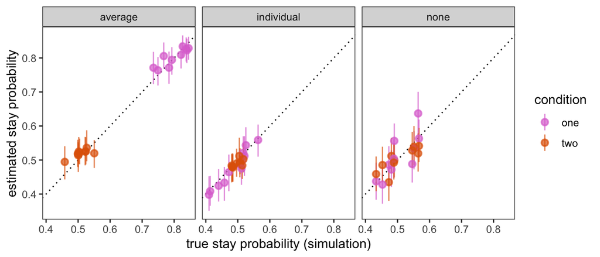

Figure 4: Each person’s stay probability (averaged over the two classes) in each condition: posterior median and 97% HPDI against the value the simulation used. Dotted line: estimate = truth.

```r
# Each person's stay probability (the average of the two classes): the
# estimate (median and 97% interval) against the value the simulation used
person_estimates <- person |>
  summarise(stay = mean(stay), .by = c(data, condition, person, .draw)) |>
  summarise(median = median(stay),
            lower = hdci_bounds(stay, 0.97)[["lower"]],
            upper = hdci_bounds(stay, 0.97)[["upper"]],
            .by = c(data, condition, person))

person_values <- person_true |>
  summarise(true = mean(stay), .by = c(data, condition, person))

left_join(person_estimates, person_values, by = c("data", "condition", "person")) |>
  ggplot(aes(true, median, colour = condition)) +
  geom_abline(linetype = "dotted") +
  geom_pointrange(aes(ymin = lower, ymax = upper), alpha = 0.7) +
  facet_wrap(~data) +
  labs(x = "true stay probability (simulation)", y = "estimated stay probability")
```

Each person’s values are recovered, with estimates pulled slightly towards their condition’s population value (shrinkage). In the **none** data each person’s two values are the same; in the other two they differ.

## 4 Which kind of difference?

```r
# (2) Which model predicts each dataset best? fomo_compare() gives loo and
# accuracy for the three models fitted to one dataset
comparison <- bind_rows(map2(fits, found, \(f, d) fomo_compare(f, list(stim = stim, found = d),
                                                               n_draws = 200)),
                        .id = "data")

format_compare(comparison, group = "data",
               columns = c("data", "model", "deterministic", "elpd_diff", "se_diff", "robust"))
```

| data | model | deterministic | elpd_diff | se_diff | robust |
| --- | --- | --- | --- | --- | --- |
| average | condition | 0.511 | 0.0 | 0.0 | TRUE |
| average | person x condition | 0.511 | -6.5 | 5.9 | NA |
| average | pooled | 0.491 | -482.1 | 30.7 | TRUE |
| individual | condition | 0.501 | 0.0 | 0.0 | TRUE |
| individual | person x condition | 0.500 | -7.5 | 4.1 | NA |
| individual | pooled | 0.492 | -369.6 | 35.3 | TRUE |
| none | condition | 0.489 | -17.4 | 7.0 | TRUE |
| none | person x condition | 0.489 | -5.5 | 6.5 | NA |
| none | pooled | 0.488 | 0.0 | 0.0 | TRUE |

`elpd_diff` is each model’s difference in loo from the best one, with its standard error.

So the two tools are complementary: loo for whether individuals change, the posterior of the population difference for whether the average does. With fewer trials per person, or leaving out whole people rather than trials (which needs predictions for new people: see `ToDo.md`), loo would depend more on the population values.

Accuracy (`deterministic`: how often the model’s most likely item is the one chosen) changes much less than loo. Which item is most likely rarely changes; how much probability the model gives the chosen item does, and loo scores that.